# IRIS

Karan Singh Aulakh

15 January 2017

## R Packages

R is an open-source programming language, meaning that users can contribute packages that make our lives easier, and we can use them for free. For this lab, and many others in the future, we will use the following R packages:

- `dplyr`: for data wrangling
- `ggplot2`: for data visualization

```r
library(datasets)
library(dplyr)
```

```r
library(ggplot2)
library(scatterplot3d)
library(rgl)
library(lattice)
```

You should have already installed these packages using commands like `install.packages` and `install_github`.

To load dataset Iris, we import package datasets which consists of Iris dataset for our experiments

```r
data(iris)
```

We first of all investigate the dimensions of our dataset Iris

```r
dim(iris)
```

```
## [1] 150   5
```

The name of variables are returned by names().

```r
names(iris)
```

```
## [1] "Sepal.Length" "Sepal.Width"  "Petal.Length" "Petal.Width"
## [5] "Species"
```

Function str() return the structure

```r
str(iris)
```

```
## 'data.frame':    150 obs. of  5 variables:
##  $ Sepal.Length: num  5.1 4.9 4.7 4.6 5 5.4 4.6 5 4.4 4.9 ...
##  $ Sepal.Width : num  3.5 3 3.2 3.1 3.6 3.9 3.4 3.4 2.9 3.1 ...
##  $ Petal.Length: num  1.4 1.4 1.3 1.5 1.4 1.7 1.4 1.5 1.4 1.5 ...
##  $ Petal.Width : num  0.2 0.2 0.2 0.2 0.2 0.4 0.3 0.2 0.2 0.1 ...
##  $ Species     : Factor w/ 3 levels "setosa","versicolor",..: 1 1 1 1 1 1 1 1 1 1 ...
```

Function attributes() return the attributes of data.

```r
attributes(iris)
```

```
## $names
## [1] "Sepal.Length" "Sepal.Width"  "Petal.Length" "Petal.Width"
## [5] "Species"
##
## $row.names
##   [1]   1   2   3   4   5   6   7   8   9  10  11  12  13  14  15  16  17
##  [18]  18  19  20  21  22  23  24  25  26  27  28  29  30  31  32  33  34
##  [35]  35  36  37  38  39  40  41  42  43  44  45  46  47  48  49  50  51
##  [52]  52  53  54  55  56  57  58  59  60  61  62  63  64  65  66  67  68
##  [69]  69  70  71  72  73  74  75  76  77  78  79  80  81  82  83  84  85
##  [86]  86  87  88  89  90  91  92  93  94  95  96  97  98  99 100 101 102
## [103] 103 104 105 106 107 108 109 110 111 112 113 114 115 116 117 118 119
## [120] 120 121 122 123 124 125 126 127 128 129 130 131 132 133 134 135 136
## [137] 137 138 139 140 141 142 143 144 145 146 147 148 149 150
##
## $class
## [1] "data.frame"
```

we can examine the first n rows of data.Here we’ll have a look at the first 10 rows of the data

```r
iris[1:10, ]
```

```
##    Sepal.Length Sepal.Width Petal.Length Petal.Width Species
## 1           5.1         3.5          1.4         0.2  setosa
## 2           4.9         3.0          1.4         0.2  setosa
## 3           4.7         3.2          1.3         0.2  setosa
## 4           4.6         3.1          1.5         0.2  setosa
## 5           5.0         3.6          1.4         0.2  setosa
## 6           5.4         3.9          1.7         0.4  setosa
## 7           4.6         3.4          1.4         0.3  setosa
## 8           5.0         3.4          1.5         0.2  setosa
## 9           4.4         2.9          1.4         0.2  setosa
## 10          4.9         3.1          1.5         0.1  setosa
```

In general, we can see the starting elements of the data sets using head()

```r
head(iris,5)
```

```
##   Sepal.Length Sepal.Width Petal.Length Petal.Width Species
## 1          5.1         3.5          1.4         0.2  setosa
## 2          4.9         3.0          1.4         0.2  setosa
## 3          4.7         3.2          1.3         0.2  setosa
## 4          4.6         3.1          1.5         0.2  setosa
## 5          5.0         3.6          1.4         0.2  setosa
```

```r
tail(iris,10)
```

```
##     Sepal.Length Sepal.Width Petal.Length Petal.Width   Species
## 141          6.7         3.1          5.6         2.4 virginica
## 142          6.9         3.1          5.1         2.3 virginica
## 143          5.8         2.7          5.1         1.9 virginica
## 144          6.8         3.2          5.9         2.3 virginica
## 145          6.7         3.3          5.7         2.5 virginica
## 146          6.7         3.0          5.2         2.3 virginica
## 147          6.3         2.5          5.0         1.9 virginica
## 148          6.5         3.0          5.2         2.0 virginica
## 149          6.2         3.4          5.4         2.3 virginica
## 150          5.9         3.0          5.1         1.8 virginica
```

A random sample of the data can be retrieved with function sample()

```r
samp<- sample(1:nrow(iris),8)
samp
```

```
## [1]  67  91 143 139   2  95  14  98
```

```r
iris[samp, ]
```

```
##     Sepal.Length Sepal.Width Petal.Length Petal.Width    Species
## 67           5.6         3.0          4.5         1.5 versicolor
## 91           5.5         2.6          4.4         1.2 versicolor
## 143          5.8         2.7          5.1         1.9  virginica
## 139          6.0         3.0          4.8         1.8  virginica
## 2            4.9         3.0          1.4         0.2     setosa
## 95           5.6         2.7          4.2         1.3 versicolor
## 14           4.3         3.0          1.1         0.1     setosa
## 98           6.2         2.9          4.3         1.3 versicolor
```

We can also retrieve the values of a single column. For example, the first 10 values of Sepal.Length can be obtained in three different ways below.

```r
iris[1:10, "Sepal.Length"]
```

```
##  [1] 5.1 4.9 4.7 4.6 5.0 5.4 4.6 5.0 4.4 4.9
```

```r
iris[1:10, 1]
```

```
##  [1] 5.1 4.9 4.7 4.6 5.0 5.4 4.6 5.0 4.4 4.9
```

```r
iris$Sepal.Length[1:10]
```

```
##  [1] 5.1 4.9 4.7 4.6 5.0 5.4 4.6 5.0 4.4 4.9
```

Distribution of every numeric variable can be checked with function summary(), which returns the minimum, maximum, mean, median, and the first (25%) and third (75%) quartiles.

```r
summary(iris)
```

```
##   Sepal.Length    Sepal.Width     Petal.Length    Petal.Width
##  Min.   :4.300   Min.   :2.000   Min.   :1.000   Min.   :0.100
##  1st Qu.:5.100   1st Qu.:2.800   1st Qu.:1.600   1st Qu.:0.300
##  Median :5.800   Median :3.000   Median :4.350   Median :1.300
##  Mean   :5.843   Mean   :3.057   Mean   :3.758   Mean   :1.199
##  3rd Qu.:6.400   3rd Qu.:3.300   3rd Qu.:5.100   3rd Qu.:1.800
##  Max.   :7.900   Max.   :4.400   Max.   :6.900   Max.   :2.500
##        Species
##  setosa    :50
##  versicolor:50
##  virginica :50
##
##
##
```

For factors (or categorical variables), it shows the frequency of every level. In the result below, we can see that each one of the three Species,setosa, versicolor and virginica, has 50 observations.

The mean, median and range can also be obtained respectively with functions with mean(), median() and range(). Quartiles and percentiles are supported by function quantile()

```r
quantile(iris$Sepal.Length)
```

```
##   0%  25%  50%  75% 100%
##  4.3  5.1  5.8  6.4  7.9
```

```r
quantile(iris$Sepal.Length, c(0.1, 0.3, 0.65))
```

```
##  10%  30%  65%
## 4.80 5.27 6.20
```

we check the variance of Sepal.Length with var()

```r
var(iris$Sepal.Length)
```

```
## [1] 0.6856935
```

We can also check its distribution with histogram and density using functions hist() and density().

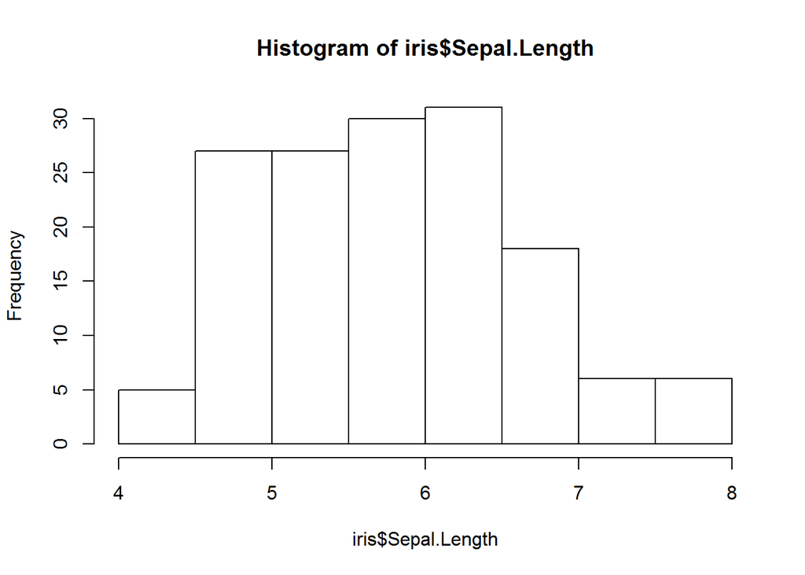

```r
hist(iris$Sepal.Length)
```

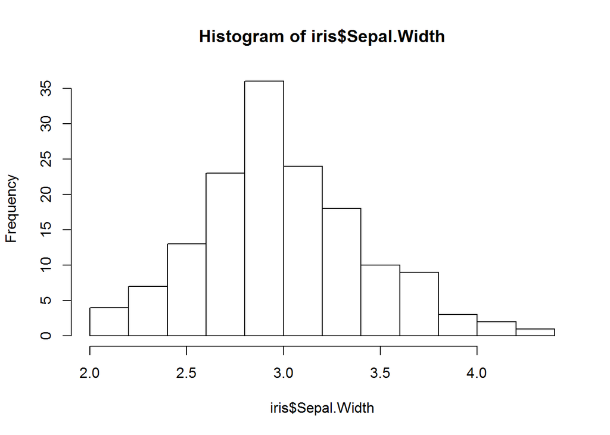

```r
hist(iris$Sepal.Width)
```

```r
density(iris$Sepal.Length)
```

```
##
## Call:
##  density.default(x = iris$Sepal.Length)
##
## Data: iris$Sepal.Length (150 obs.);  Bandwidth 'bw' = 0.2736
##
##        x               y
##  Min.   :3.479   Min.   :0.0001495
##  1st Qu.:4.790   1st Qu.:0.0341599
##  Median :6.100   Median :0.1534105
##  Mean   :6.100   Mean   :0.1905934
##  3rd Qu.:7.410   3rd Qu.:0.3792237
##  Max.   :8.721   Max.   :0.3968365
```

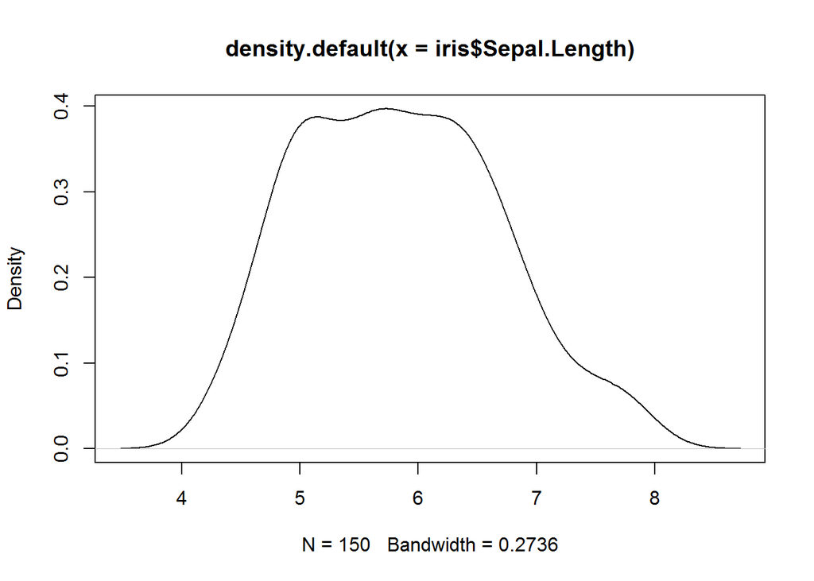

```r
plot(density(iris$Sepal.Length))
```

The frequency of a factor variable can be calculated with function table()

```r
table(iris$Species)
```

```
##
##     setosa versicolor  virginica
##         50         50         50
```

```r
table(iris$Petal.Length)
```

```
##
##   1 1.1 1.2 1.3 1.4 1.5 1.6 1.7 1.9   3 3.3 3.5 3.6 3.7 3.8 3.9   4 4.1
##   1   1   2   7  13  13   7   4   2   1   2   2   1   1   1   3   5   3
## 4.2 4.3 4.4 4.5 4.6 4.7 4.8 4.9   5 5.1 5.2 5.3 5.4 5.5 5.6 5.7 5.8 5.9
##   4   2   4   8   3   5   4   5   4   8   2   2   2   3   6   3   3   2
##   6 6.1 6.3 6.4 6.6 6.7 6.9
##   2   3   1   1   1   2   1
```

The tables can be represented as a pie chart with pie() or a bar chart with barplot().

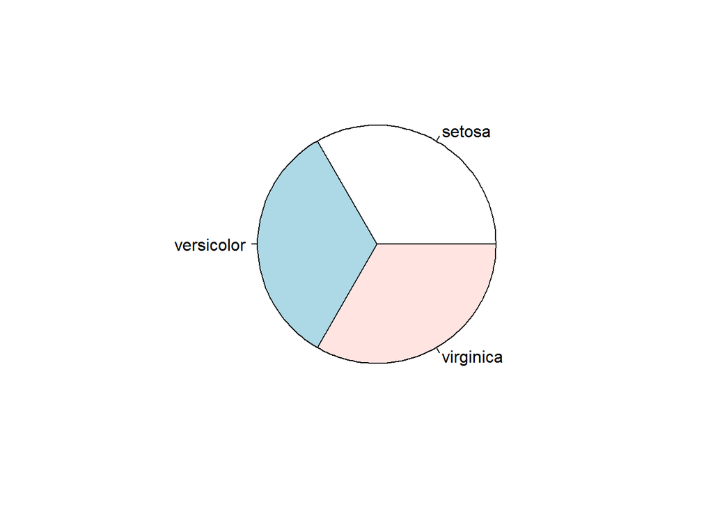

```r
pie(table(iris$Species))
```

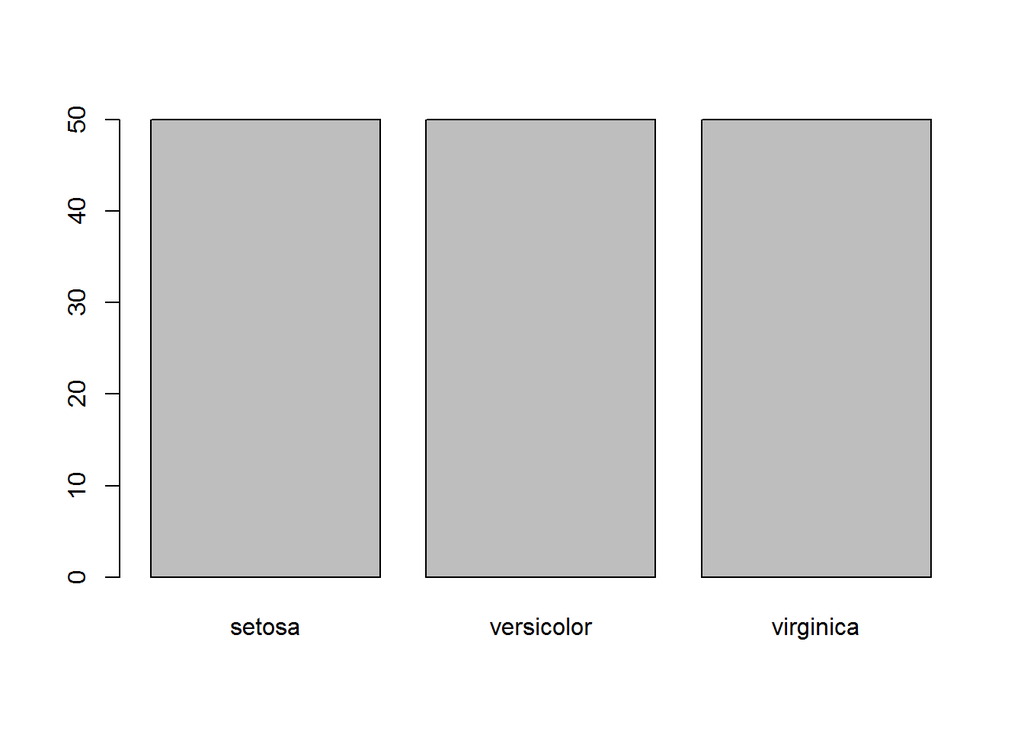

```r
barplot(table(iris$Species))
```

we calculate covariance and correlation between variables with cov() and cor()

```r
cov(iris$Sepal.Length,iris$Sepal.Width)
```

```
## [1] -0.042434
```

```r
cov(iris[1:4],)
```

```
##              Sepal.Length Sepal.Width Petal.Length Petal.Width
## Sepal.Length    0.6856935  -0.0424340    1.2743154   0.5162707
## Sepal.Width    -0.0424340   0.1899794   -0.3296564  -0.1216394
## Petal.Length    1.2743154  -0.3296564    3.1162779   1.2956094
## Petal.Width     0.5162707  -0.1216394    1.2956094   0.5810063
```

```r
cor(iris$Sepal.Length,iris$Sepal.Width)
```

```
## [1] -0.1175698
```

```r
cor(iris[1:4],)
```

```
##              Sepal.Length Sepal.Width Petal.Length Petal.Width
## Sepal.Length    1.0000000  -0.1175698    0.8717538   0.8179411
## Sepal.Width    -0.1175698   1.0000000   -0.4284401  -0.3661259
## Petal.Length    0.8717538  -0.4284401    1.0000000   0.9628654
## Petal.Width     0.8179411  -0.3661259    0.9628654   1.0000000
```

We can use the aggregate function to compute the statistics of the different species of the dataset as well

```r
aggregate(Sepal.Length~Species, summary, data=iris)
```

```
##      Species Sepal.Length.Min. Sepal.Length.1st Qu. Sepal.Length.Median
## 1     setosa             4.300                4.800               5.000
## 2 versicolor             4.900                5.600               5.900
## 3  virginica             4.900                6.225               6.500
##   Sepal.Length.Mean Sepal.Length.3rd Qu. Sepal.Length.Max.
## 1             5.006                5.200             5.800
## 2             5.936                6.300             7.000
## 3             6.588                6.900             7.900
```

```r
aggregate(Petal.Length~Species, summary, data=iris)
```

```
##      Species Petal.Length.Min. Petal.Length.1st Qu. Petal.Length.Median
## 1     setosa             1.000                1.400               1.500
## 2 versicolor             3.000                4.000               4.350
## 3  virginica             4.500                5.100               5.550
##   Petal.Length.Mean Petal.Length.3rd Qu. Petal.Length.Max.
## 1             1.462                1.575             1.900
## 2             4.260                4.600             5.100
## 3             5.552                5.875             6.900
```

We use function boxplot() to plot a box plot, also known as box-and-whisker plot, to show the median, first and third quartile of a distribution (i.e., the 50%, 25% and 75% points in cumulative distribution), and outliers. The bar in the middle is the median. The box shows the interquartile range (IQR), which is the range between the 75% and 25% observation.

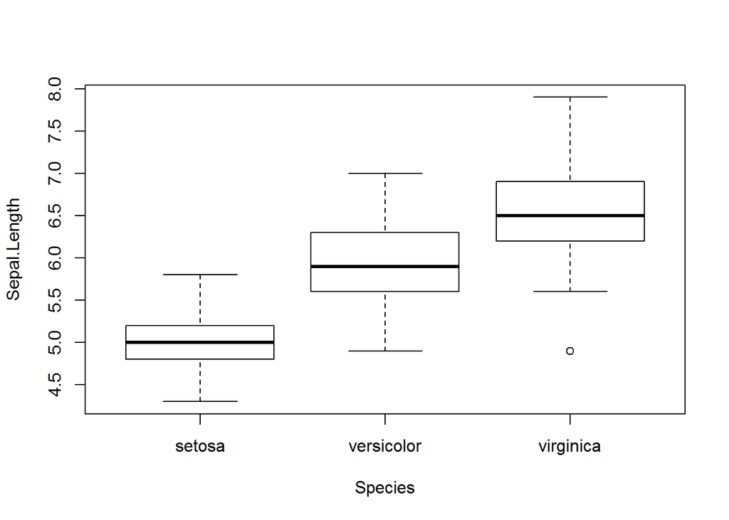

```r
boxplot(Sepal.Length ~ Species, data=iris, xlab="Species", ylab="Sepal.Length")
```

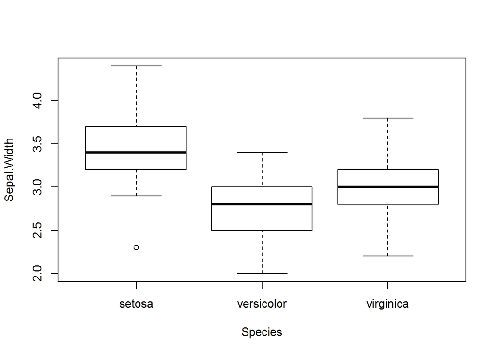

```r
boxplot(Sepal.Width ~ Species, data=iris, xlab="Species", ylab="Sepal.Width")
```

A scatter plot can be drawn for two numeric variables with plot() and with() as well.

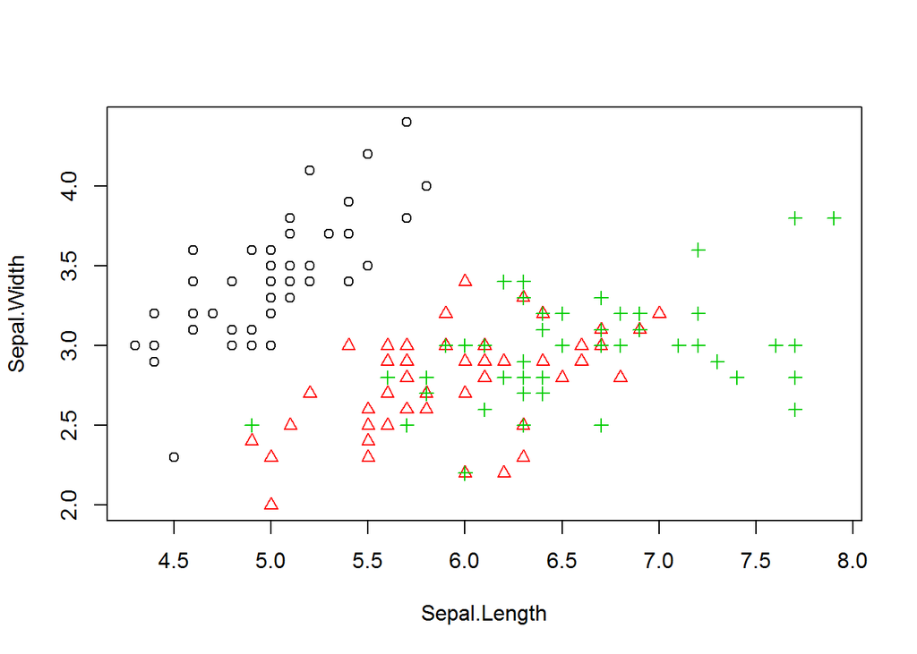

```r
 with(iris, plot(Sepal.Length, Sepal.Width, col=Species, pch=as.numeric(Species)))
```

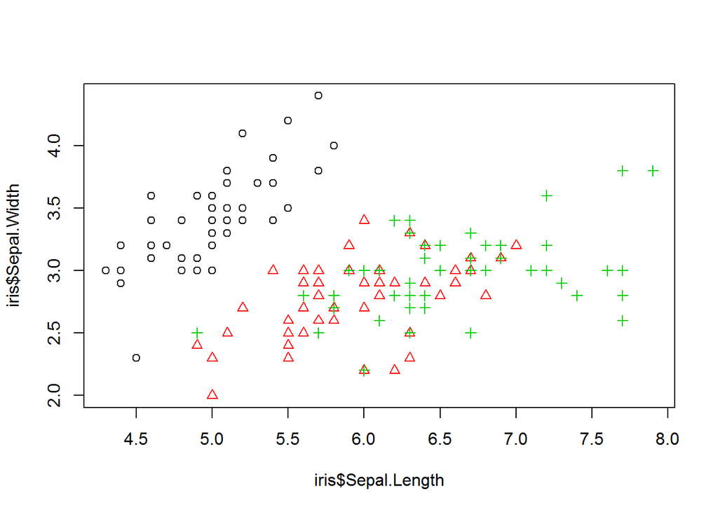

```r
 ## same function as above
plot(iris$Sepal.Length, iris$Sepal.Width, col=iris$Species, pch=as.numeric(iris$Species))
```

When there are many points, some of them may overlap. We can use jitter() to add a small amount of noise to the data before plotting.

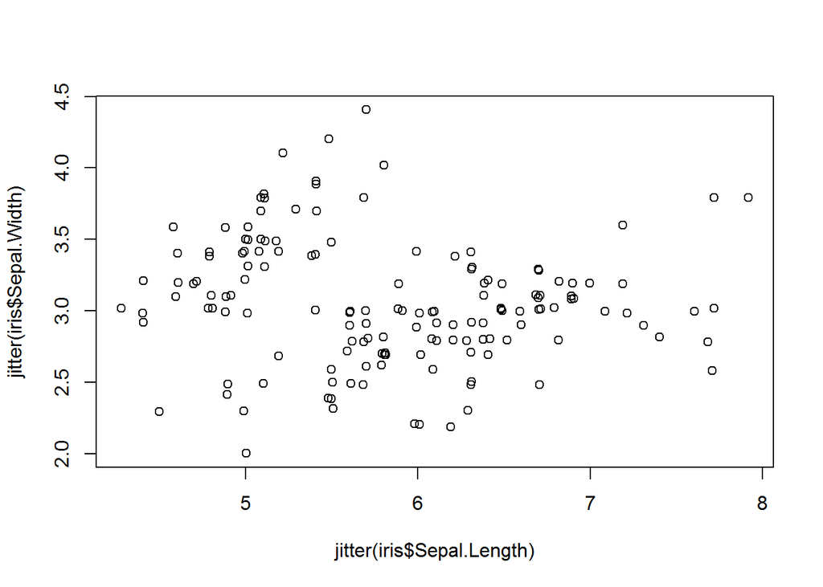

```r
plot(jitter(iris$Sepal.Length), jitter(iris$Sepal.Width))
```

A smooth scatter plot can be plotted with function smoothScatter(), which a smoothed color density representation of the scatterplot, obtained through a kernel density estimate.

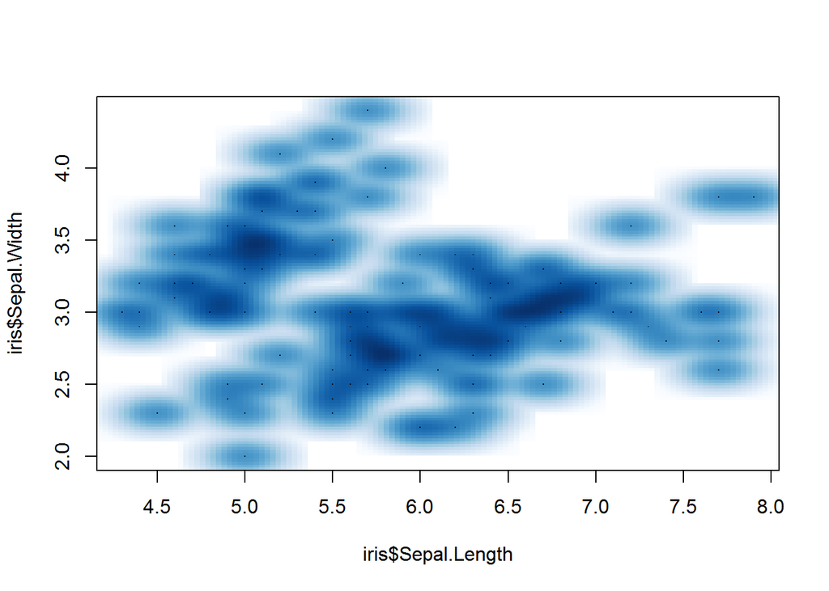

```r
smoothScatter(iris$Sepal.Length, iris$Sepal.Width)
```

A matrix of scatter plots can be produced with function pairs(), where each sub figure is the scatter plot of a pair of variables.

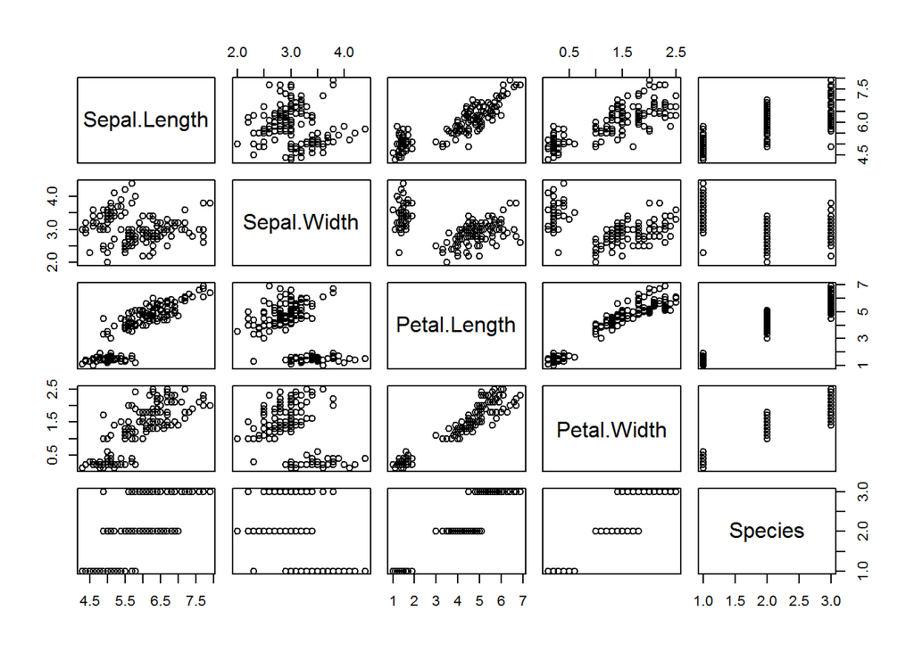

```r
pairs(iris)
```

A 3D scatterplot to assess the relation between multiple variables

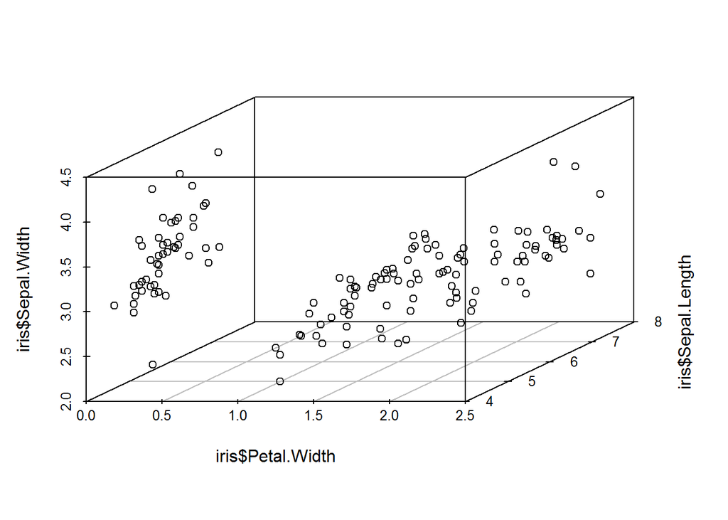

```r
scatterplot3d(iris$Petal.Width, iris$Sepal.Length, iris$Sepal.Width)
```

```r
plot3d(iris$Petal.Width, iris$Sepal.Length, iris$Sepal.Width)
```

A heat map presents a 2D display of a data matrix, which can be generated with heatmap().We calculate the similarity between different flowers in the iris data with dist() and then plot it with a heat map.

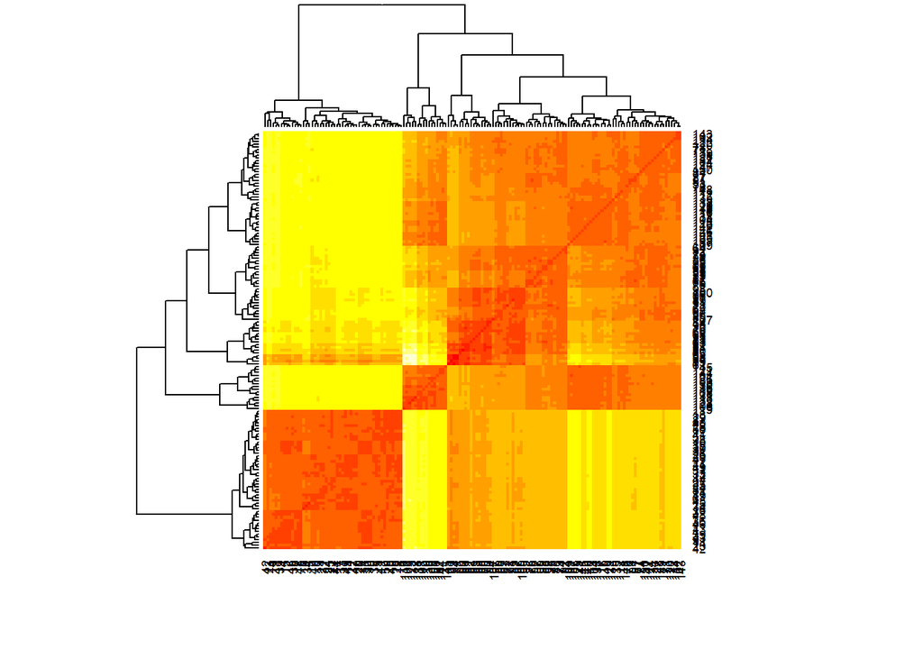

```r
distMatrix <- as.matrix(dist(iris[,1:4]))
heatmap(distMatrix)
```

A level plot can be produced with function levelplot() in package lattice. Function grey.colors() creates a vector of gamma-corrected gray colors.

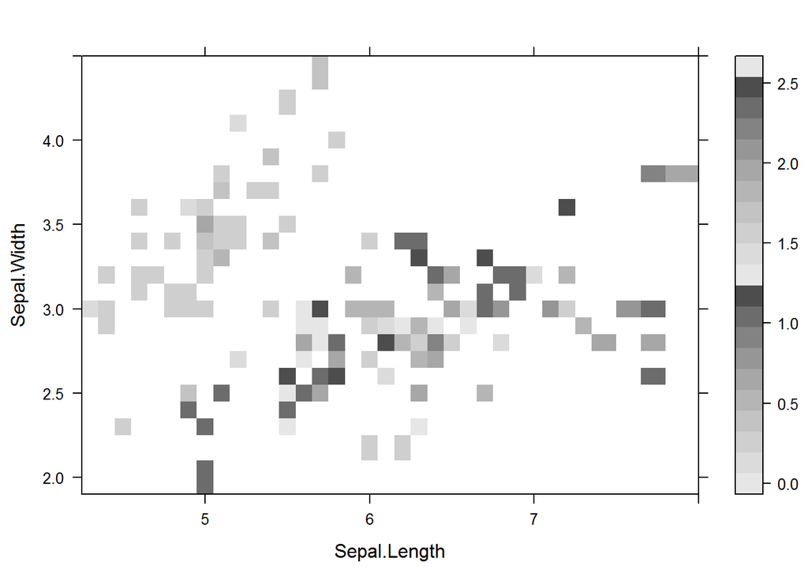

```r
library(lattice)
levelplot(Petal.Width~Sepal.Length*Sepal.Width, iris,cuts=20,col.regions=grey.colors(10)[10:1])
```

Contour plots can be plotted with contour() and filled.contour() in package graphics, and with contourplot() in package lattice.

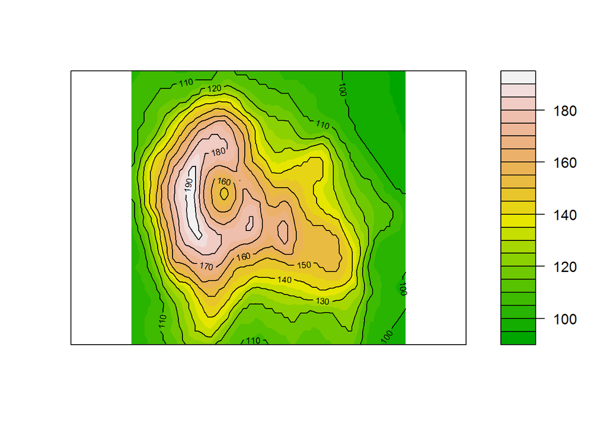

```r
library(lattice)

filled.contour(volcano, color=terrain.colors, asp=1,plot.axes=contour(volcano, add=T))
```

Parallel plots with the relation among different species’s charactertistics can be represented as below:

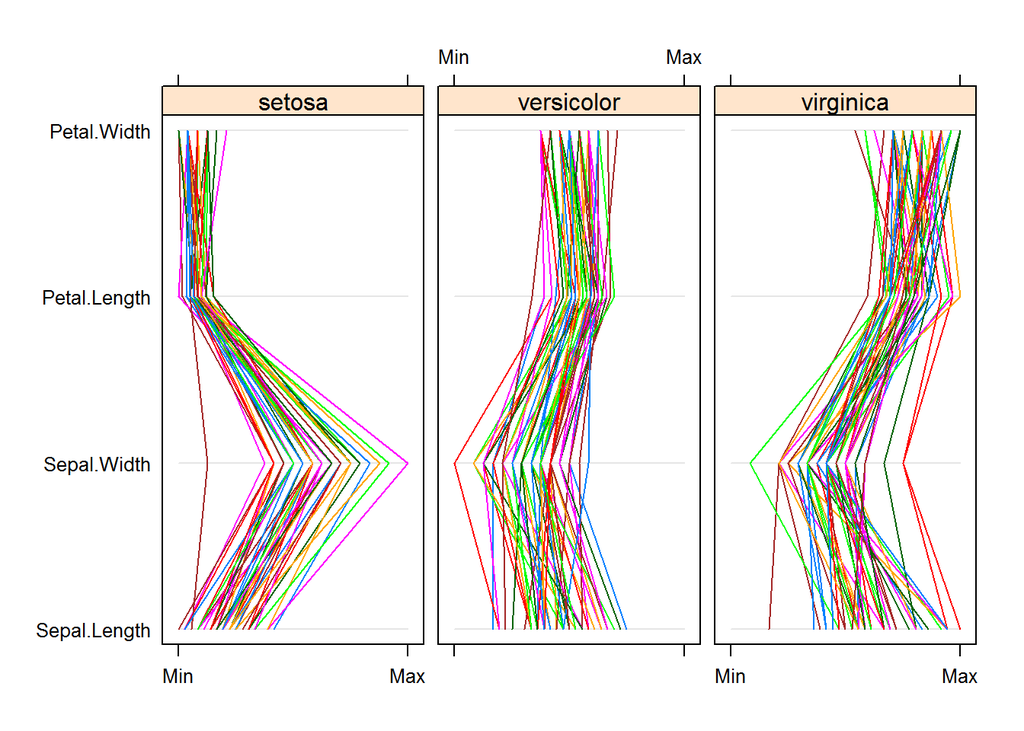

```r
library(lattice)

parallelplot(~iris[1:4] | Species, data=iris)
```

The scatterplot that determines the relation between the sepal length and sepal width ordered by the different species of the dataset

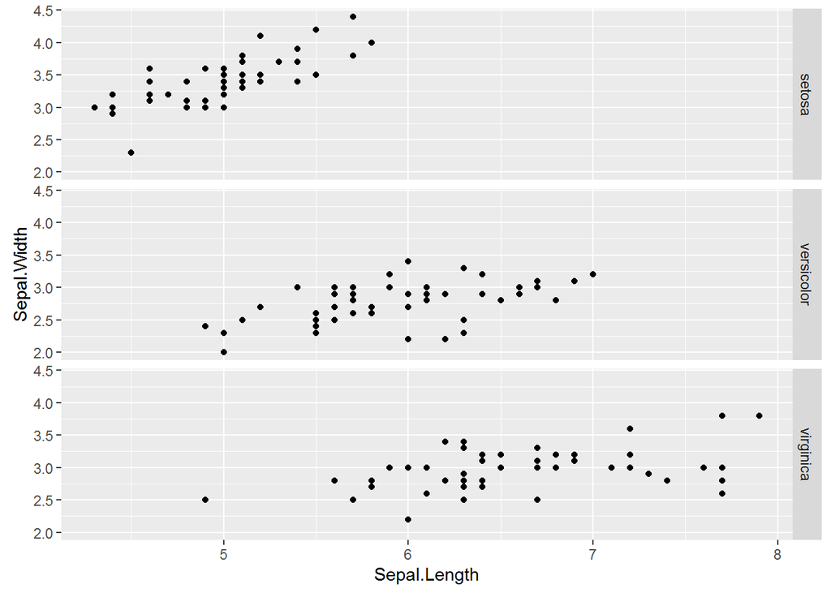

```r
library(ggplot2)
qplot(Sepal.Length, Sepal.Width, data=iris, facets=Species ~.)
```

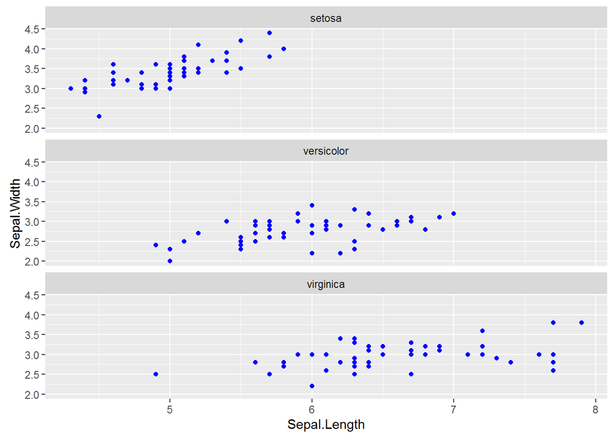

```r
## We could also apply this code for the required scatterplot
ggplot(aes(x=Sepal.Length,y=Sepal.Width),data=iris)+geom_point(color='Blue')+facet_wrap(~Species,ncol=1)
```

To build a decision tree for the iris data we use function ctree() in package party. In the package, function ctree() builds a decision tree, and predict() makes prediction for new data.

Before modeling, the iris data is split below into two subsets: training (70%) and test (30%).

The random seed is set to a fixed value below to make the results reproducible.

```r
str(iris)
```

```
## 'data.frame':    150 obs. of  5 variables:
##  $ Sepal.Length: num  5.1 4.9 4.7 4.6 5 5.4 4.6 5 4.4 4.9 ...
##  $ Sepal.Width : num  3.5 3 3.2 3.1 3.6 3.9 3.4 3.4 2.9 3.1 ...
##  $ Petal.Length: num  1.4 1.4 1.3 1.5 1.4 1.7 1.4 1.5 1.4 1.5 ...
##  $ Petal.Width : num  0.2 0.2 0.2 0.2 0.2 0.4 0.3 0.2 0.2 0.1 ...
##  $ Species     : Factor w/ 3 levels "setosa","versicolor",..: 1 1 1 1 1 1 1 1 1 1 ...
```

```r
set.seed(1234)
ind <- sample(2, nrow(iris), replace=TRUE, prob=c(0.7, 0.3))
trainData <- iris[ind==1,]
testData <- iris[ind==2,]

library(party)
myFormula <- Species ~ Sepal.Length + Sepal.Width + Petal.Length + Petal.Width
iris_ctree <- ctree(myFormula, data=trainData)
# check the prediction
table(predict(iris_ctree), trainData$Species)
```

```
##
##              setosa versicolor virginica
##   setosa         40          0         0
##   versicolor      0         37         3
##   virginica       0          1        31
```

```r
print(iris_ctree)
```

```
##
##   Conditional inference tree with 4 terminal nodes
##
## Response:  Species
## Inputs:  Sepal.Length, Sepal.Width, Petal.Length, Petal.Width
## Number of observations:  112
##
## 1) Petal.Length <= 1.9; criterion = 1, statistic = 104.643
##   2)*  weights = 40
## 1) Petal.Length > 1.9
##   3) Petal.Width <= 1.7; criterion = 1, statistic = 48.939
##     4) Petal.Length <= 4.4; criterion = 0.974, statistic = 7.397
##       5)*  weights = 21
##     4) Petal.Length > 4.4
##       6)*  weights = 19
##   3) Petal.Width > 1.7
##     7)*  weights = 32
```

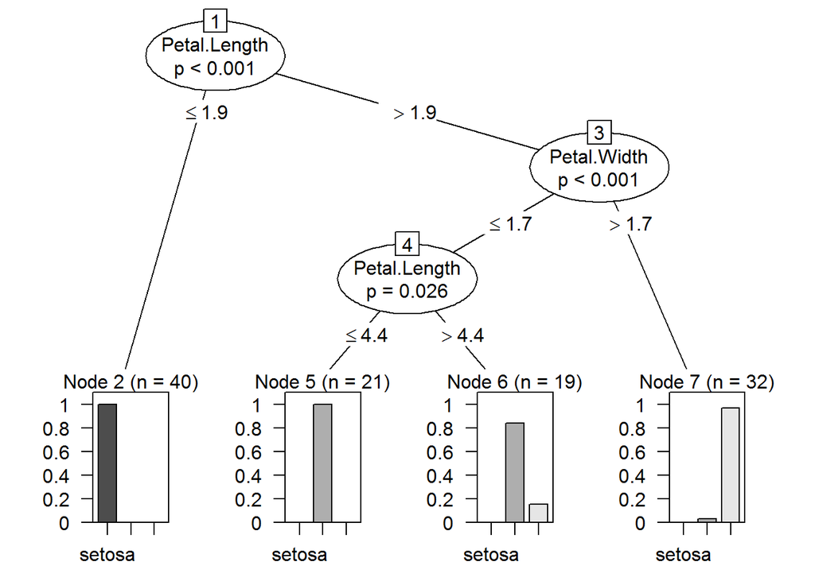

```r
#plot for the iris tree
plot(iris_ctree)
```